# Lab 11: Hurricanes Solutions

April 20, 2015

Topics covered in this lab include:

- getting data and preparing it for analysis
- dplyr
- ggplot2
- Negative binomial regression

## Goals

- Explore some issues and solutions in the hurricane study
- Understand negative binomial regression in terms of predicted counts
- Discuss ethics involved with hurricane study

## Review of Poisson Models

- With a Poisson model, we can model count data.
- An important feature of Poisson data is that the mean is equal to the variance.
- With count data, what kind of numbers will we never have?
  - Negative
- Thus, how should we deal with this? (Hint: think back to logits)
  - Take the log of the outcome
  - How would we write this? $log(\mu_i) = x_i^\prime \beta$
  - Ok, now if we just wanted the left side in terms of $\mu$? $\mu_i=e^{x_i^\prime\beta}$
- Negative binomial regression
  - Starts with a standard Poisson model and adds a random effect (theta) to represent unobserved heterogeneity

** From Kristin Bietsch: WWS 509 Generalized Linear Models: Precept 6 Introduction to Poisson Models

## Are female hurricanes deadlier than male hurricanes?

- This was originally going to be a homework assignment that we have converted it into a lab. Read through the steps to prepare the data and then begin plotting the graphs.

Rather than giving you a clean dataset, you are going to get the data and get it ready for analysis. This is a key part of the data analysis pipeline that you need to practice. And, throughout the semester we will keep coming back to this dataset, so try to write reusable code.

In this homework, we’re going to work with the data from this study: [Female hurricances are deadlier than male hurricances](http://dx.doi.org/10.1073/pnas.1402786111). First, read the introduction, archival study, materials and methods, and supporting online materials. This is actually pretty short so don’t worry.

1. **Get the Excel spreadsheet that contains the data used for the archival hurricane study and put in a subdirectory called data. You can find the data file here: http://www.pnas.org/content/suppl/2014/05/30/1402786111.DCSupplemental/pnas.1402786111.sd01.xlsx. Bonus points if you can do this directly from R (i.e., without using a web browser or a GUI.)**

```r
rm(list=ls()) # clear everything before beginning


system("mkdir data")
download.file(url = "http://www.pnas.org/content/suppl/2014/05/30/1402786111.DCSupplemental/pnas.1402786111.sd01.xlsx",
              destfile = "data/hurricane-raw-data.xlsx")
```

2. **Next, read the correct sheet of the xlsx spreadsheet into R and save it with the name `hurricanes_raw`.**

```r
library(xlsx)
hurricanes_raw <- read.xlsx(file = "data/hurricane-raw-data.xlsx",
                           sheetName = "Archival Study")
```

Now, thinking about Roger Peng’s pipeline picture, we are going to go from the “measured data” to the “analytic data”. This is sometimes called data cleaning. It can be annoying, but it is neccesary.

3. **Convert `hurricanes_raw` to a tbl. But, something is weird with the tbl. Notice all the “Notes” at the end; you can also see these directly in the Excel spreadsheet. Get rid of the “Notes”. And, give the variables sensible and consistent names that follow Google R Style Guidelines (Naming variables in an art; try to get good at it). Save this new cleaned up data.frame as `hurricanes`. Putting in all this work up front will actually make this analysis much easier (and more fun).**

```r
library(dplyr)
hurricanes <- tbl_df(hurricanes_raw)
hurricanes <- filter(hurricanes, !is.na(Name))
hurricanes <- rename(hurricanes, name = Name)
hurricanes <- rename(hurricanes, year = Year)
hurricanes <- rename(hurricanes, name_mas_fem = MasFem)
hurricanes <- rename(hurricanes, min_pressure_before = MinPressure_before)
hurricanes <- rename(hurricanes, min_pressure_updated_2014 = Minpressure_Updated.2014)
hurricanes <- rename(hurricanes, female = Gender_MF) # Note: think about why I did it this way
hurricanes <- rename(hurricanes, category = Category)
hurricanes <- rename(hurricanes, all_deaths = alldeaths)
hurricanes <- rename(hurricanes, normalized_damage = NDAM)
hurricanes <- rename(hurricanes, elapsed_years = Elapsed.Yrs)
hurricanes <- rename(hurricanes, source = Source)
hurricanes <- rename(hurricanes, name_mas_fem_z = ZMasFem)
hurricanes <- rename(hurricanes, normalized_damage_z = ZNDAM)
```

```r
# almost done but we have the problem of `ZMinPressure_A`
# is that the z score of min_pressure_before or min_pressure_updated_2014?
z_score_updated <- (hurricanes$min_pressure_updated_2014 - mean(hurricanes$min_pressure_updated_2014))/sd(hurricanes$min_pressure_updated_2014)

z_score_updated - hurricanes$ZMinPressure_A
```

```
##  [1]  0.0986630803 -0.0087034856  0.0159376599  0.0175804029  0.0159376599
##  [6] -0.0045966280 -0.0095248572 -0.0226668015 -0.0029538850  0.0175804029
## [11] -0.0045966280  0.0077239447 -0.0160958293  0.0151162884 -0.0128103432
## [16] -0.0292377736  0.0126521738 -0.0284164021  0.0249727466  0.0019743441
## [21]  0.0003316011 -0.0128103432  0.0069025732 -0.0144530863  0.0134735454
## [26]  0.0142949169 -0.0128103432  0.0093666878 -0.0464865755 -0.0169172008
## [31]  0.0101880593  0.0110094308  0.0241513751  0.0118308023 -0.0111676002
## [36] -0.0087034856  0.0118308023  0.0241513751  0.0167590314  0.0036170871
## [41] -0.0160958293 -0.0169172008 -0.0029538850 -0.0136317148  0.0823522014
## [46]  0.0175804029 -0.0054179996 -0.0193813154  0.0044384587  0.0011529726
## [51]  0.0200445175  0.0200445175  0.0225086321  0.0151162884  0.0167590314
## [56] -0.0259522875  0.0142949169 -0.0029538850 -0.0358087457  0.0478545977
## [61]  0.0060812017 -0.0193813154  0.0069025732 -0.0095248572  0.0151162884
## [66] -0.0013111420  0.0175804029 -0.0013111420 -0.0119889717 -0.0078821141
## [71] -1.1887977885 -0.0021325135  0.0110094308 -0.0070607426  0.0052598302
## [76] -0.0202026869 -0.0045966280  0.0159376599 -0.0160958293 -0.0128103432
## [81]  0.0208658890 -0.0160958293  0.0134735454 -0.0234881730 -0.0128103432
## [86]  0.0159376599  0.2076723894  0.1453647054  0.7616374697 -0.0111676002
## [91]  0.0519614553 -0.1742708780
```

```r
# ok these are different

z_score_before <- (hurricanes$min_pressure_before - mean(hurricanes$min_pressure_before))/sd(hurricanes$min_pressure_before)

z_score_before - hurricanes$ZMinPressure_A
```

```
##  [1] -1.137979e-14 -1.121325e-14 -1.287859e-14 -1.310063e-14 -1.287859e-14
##  [6] -1.143530e-14 -1.110223e-14 -1.021405e-14 -1.157408e-14 -1.310063e-14
## [11] -1.143530e-14 -1.232348e-14 -1.065814e-14 -1.287859e-14 -1.088019e-14
## [16] -9.769963e-15 -1.265654e-14 -9.769963e-15 -1.354472e-14 -1.190714e-14
## [21] -1.180306e-14 -1.088019e-14 -1.226796e-14 -1.076916e-14 -1.276756e-14
## [26] -1.276756e-14 -1.088019e-14 -1.243450e-14 -8.437695e-15 -1.065814e-14
## [31] -1.243450e-14 -1.254552e-14 -1.332268e-14 -1.254552e-14 -1.099121e-14
## [36] -1.121325e-14 -1.254552e-14 -1.332268e-14 -1.287859e-14 -1.204592e-14
## [41] -1.065814e-14 -1.065814e-14 -1.157408e-14 -1.076916e-14 -1.376677e-14
## [46] -1.310063e-14 -1.137979e-14 -1.043610e-14 -1.210143e-14 -1.186551e-14
## [51] -1.310063e-14 -1.310063e-14 -1.332268e-14 -1.287859e-14 -1.287859e-14
## [56] -9.992007e-15 -1.276756e-14 -1.157408e-14 -9.325873e-15 -1.143530e-14
## [61] -1.221245e-14 -1.043610e-14 -1.226796e-14 -1.110223e-14 -1.287859e-14
## [66] -1.168510e-14 -1.310063e-14 -1.168510e-14 -1.099121e-14 -1.121325e-14
## [71] -1.310063e-14 -1.164346e-14 -1.254552e-14 -1.132427e-14 -1.210143e-14
## [76] -1.043610e-14 -1.143530e-14 -1.287859e-14 -1.065814e-14 -1.088019e-14
## [81] -1.332268e-14 -1.065814e-14 -1.276756e-14 -9.992007e-15 -1.088019e-14
## [86] -1.287859e-14 -1.164346e-14 -1.099121e-14 -9.992007e-15 -1.099121e-14
## [91] -1.174148e-14 -1.065814e-14
```

```r
all((z_score_before - hurricanes$ZMinPressure_A) < 0.00001)
```

```
## [1] TRUE
```

```r
# Why did I subtract them and check if they are less than 0.00001?
# This has to do with how the computer stores numbers.
# To learn more read this from the R FAQ: http://cran.r-project.org/doc/FAQ/R-FAQ.html#Why-doesn_0027t-R-think-these-numbers-are-equal_003f
# Or watch this part Martin Mächler's Keynote Speech from useR 2014 "Good Practices in R Programming": https://www.youtube.com/watch?v=ytbX-T1A8wE?#t=43m00s

# ok the right answer is that ZMinPressure_A is the z.score of min_pressure_before

hurricanes <- rename(hurricanes, min_pressure_before_z = ZMinPressure_A)

# Note they stored the Z score of what appears to be the old measure of MinPressure.  I'm not sure what is going on here.  This is a good example of why you want to store normalized data.
```

Finally, there is one little anoying thing left. year is current stored as a factor and it has some junk in it. You can see that like this.

```r
is.factor(hurricanes$year)
```

```
## [1] TRUE
```

```r
levels(hurricanes$year)
```

```
##  [1] " Reanalysis with these data did not alter the conclusions. The modifications were: Hurricane Easy (1950:  958 to 960mb), Hurricane Bob (1985: 1002 to 1003mb), Hurricane Emily (1993: 960 to 961mb), "
##  [2] "1. Our analyses were based on data obtained from NOAA and ICAT web sources in January, 2013.  Subsequently NOAA made slight modifications to minimum pressure data for 7 hurricanes."
##  [3] "1950"
##  [4] "1952"
##  [5] "1953"
##  [6] "1954"
##  [7] "1955"
##  [8] "1956"
##  [9] "1958"
## [10] "1959"
## [11] "1960"
## [12] "1961"
## [13] "1963"
## [14] "1964"
## [15] "1965"
```

[output cut: 39 more lines]

To remove this junk convert the factor to a numeric like this: as.numeric(as.character(f)) More concretely:

```r
hurricanes$year <- as.numeric(as.character(hurricanes$year))
str(hurricanes$year)
```

```
##  num [1:92] 1950 1950 1952 1953 1953 ...
```

I know that this is annoying. Sorry.

4. **How many hurricanes are in your dataset?**

```r
nrow(hurricanes)
```

```
## [1] 92
```

5. **Does this match the number analyzed in the paper.**

```
yes
```

# OK, now let’s start graphing the data to understand it better.

6. **Make a plot that shows the death toll as a function of the femininity of the name of the hurricane. Include a loess smoother on the plot.**

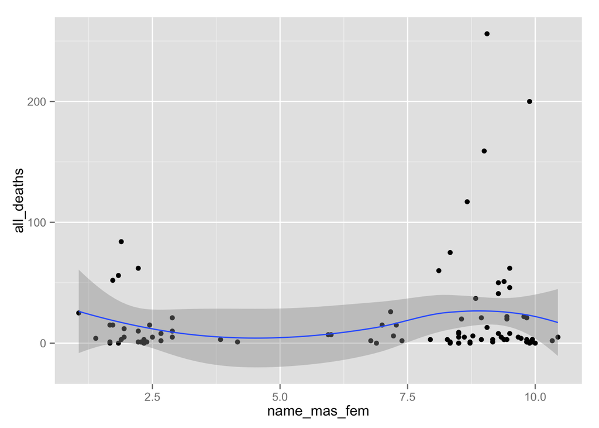

```r
library(ggplot2)
p <- ggplot(hurricanes, aes(x=name_mas_fem, y=all_deaths))
p + geom_point() +
  stat_smooth(method = "loess")
```

[output not shown]

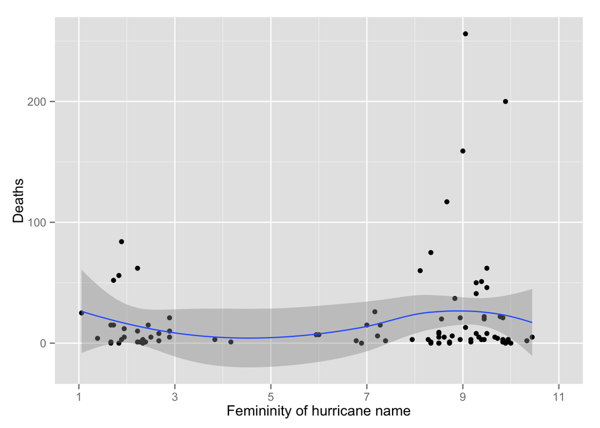

```r
# we can also clean this up a bit
p <- ggplot(hurricanes, aes(x=name_mas_fem, y=all_deaths))
p + geom_point() +
  scale_x_continuous(name="Femininity of hurricane name", limits=c(1,11), breaks=c(1, 3, 5, 7, 9, 11)) +
  scale_y_continuous(name="Deaths") +
  stat_smooth()
```

7. **In words, what would you conclude from this graph?**

There does not appear to be a strong relationship between the femininity of hurricane name and the number of deaths it causes.

To foreshadow what is coming in the future, we are going to try to account for the fact that the storms with feminine names might be different from the storms of masculine names. This is what researchers sometimes call “controlling”.

8. **Make a plot that shows how the femininity of hurrican names has changed over time. The naming convention whereby hurricane names alternated between male and female was implimented in 1979. Please include this information in the graph.**

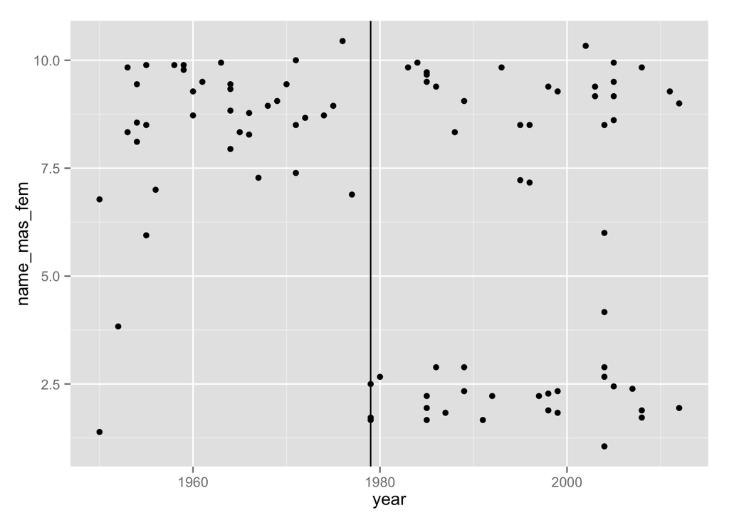

```r
p <- ggplot(hurricanes, aes(x=year, y=name_mas_fem))
p + geom_point() +
  geom_vline(xintercept = 1979)
```

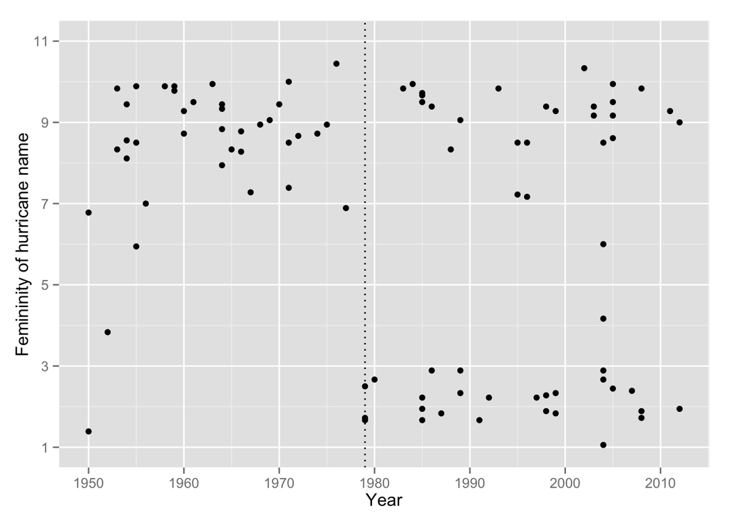

```r
# we can also clean this up a bit
p <- ggplot(hurricanes, aes(x=year, y=name_mas_fem))
p + geom_point() +
  geom_vline(xintercept=1979, linetype="dotted") +
  scale_y_continuous(name="Femininity of hurricane name", limits=c(1, 11), breaks=c(1, 3, 5, 7, 9, 11)) +
  scale_x_continuous(name="Year", breaks=c(1950, 1960, 1970, 1980, 1990, 2000, 2010))
```

9. **Make a plot that shows the relationship between minimum pressure and deaths.**

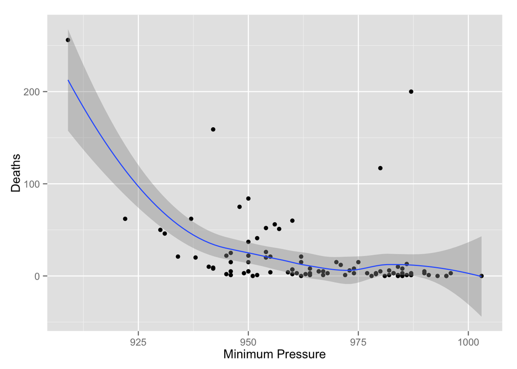

```r
p <- ggplot(hurricanes, aes(x=min_pressure_updated_2014, y=all_deaths))
p + geom_point() +
  stat_smooth(method = "loess") +
  scale_x_continuous(name="Minimum Pressure") +
  scale_y_continuous(name="Deaths")
```

10. **Make a plot that shows the relationship between normalized damage and deaths.**

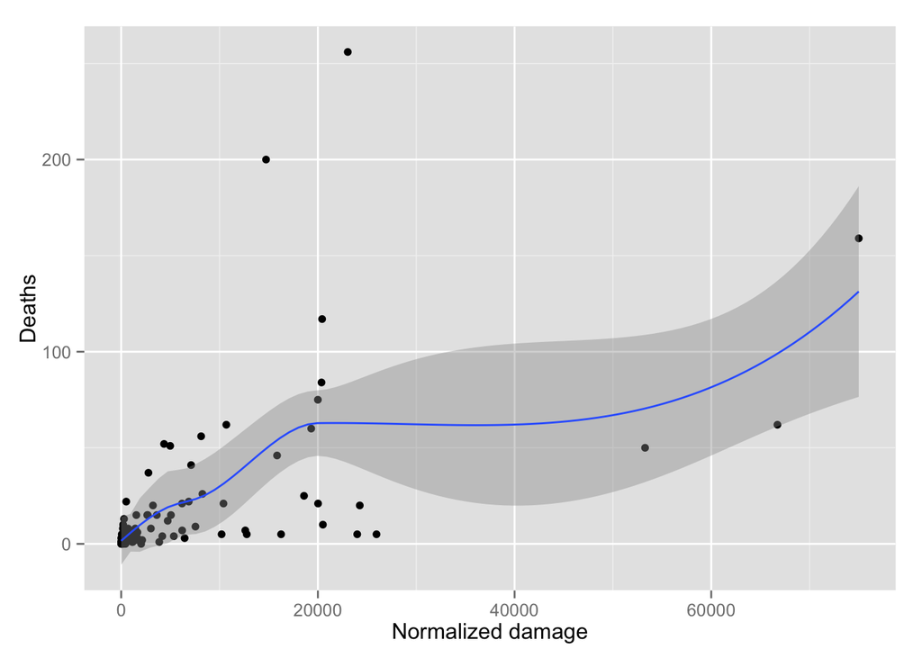

```r
p <- ggplot(hurricanes, aes(x=normalized_damage, y=all_deaths))
p + geom_point() +
  stat_smooth(method = "loess") +
  scale_x_continuous(name="Normalized damage") +
  scale_y_continuous(name="Deaths")
```

11. **Using dplyr, make a data.frame showing the number of storms in each category (e.g., 1 to 5).

```r
hurricanes %>%
  group_by(category) %>%
  summarise(count=n())
```

```
## Source: local data frame [5 x 2]
##
##   category count
## 1        1    36
## 2        2    21
## 3        3    28
## 4        4     5
## 5        5     2
```

12. **Make a plot showing the distribution of deaths for storms of each category.**

[output not shown]

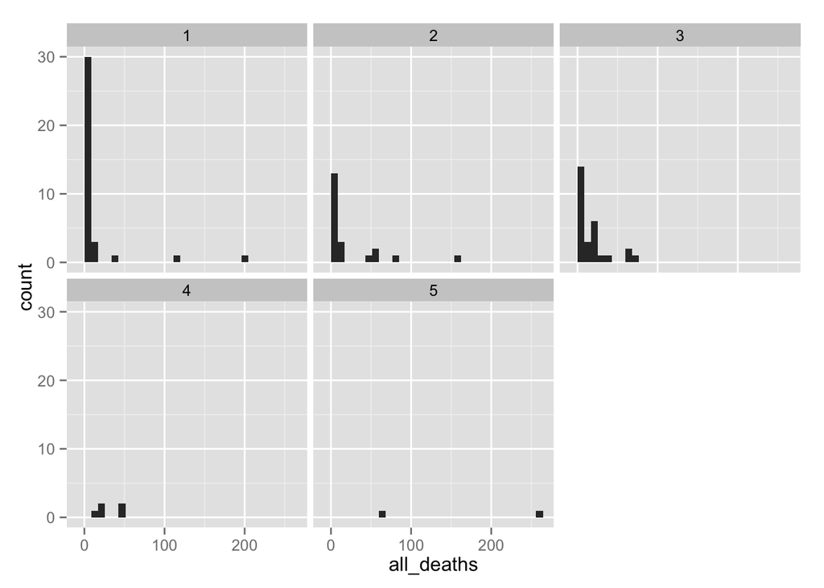

```r
p <- ggplot(hurricanes, aes(x=all_deaths))
p + geom_histogram() +
  facet_wrap( ~ category)
```

[output not shown]

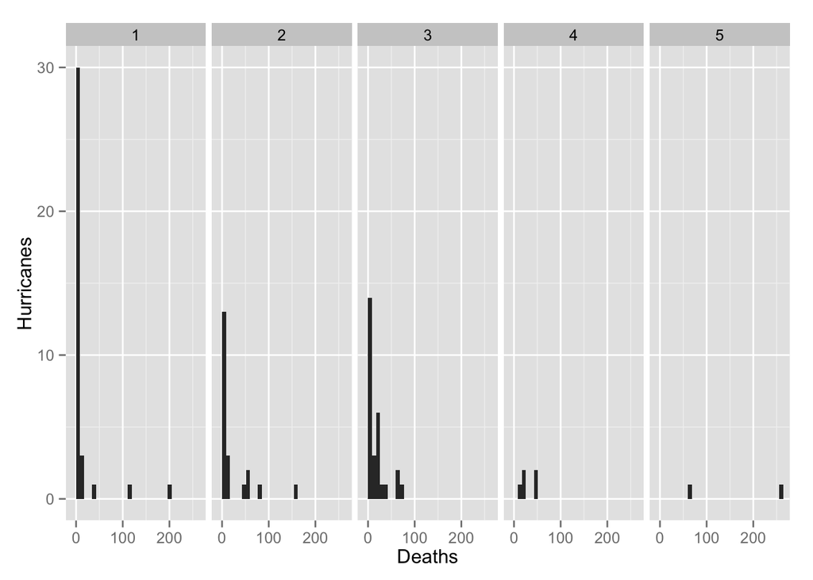

```r
# now let's clean it up a bit
p <- ggplot(hurricanes, aes(x=all_deaths))
p + geom_histogram() +
  facet_wrap( ~ category, ncol=5) +
  scale_x_continuous(name="Deaths") +
  scale_y_continuous(name="Hurricanes")
```

## Practice with Negative binomial regression

- Run a negative binomial regression for Model 1 of the deaths on minimized pressure (use “min_pressure_before”, not “min_pressure_updated_2014”)
- For model 2, add Normalized damage and Mas-fem index (MFI)
- For model 3, add the interaction of MFI with minimum pressure and also the interaction of MFI with normalized damage.
- Freese argues “The significant coefficients in their key model both become nonsignificant and presumably nonpublishable (p > .25) if we drop only two hurricanes: Andrew and Diane (which killed 200 people in 1955).” Verify this for yourself in model 3.
- Returning to the original model 3 (with all 92 hurricanes), make a scatter plot of actual death counts vs. the predicted (fitted.values) counts.
- Calculate the predicted counts of fatalities for a MFI score of 1 and 11. Use the observed value approach and graph the results.

```r
#install.packages("MASS")
library(MASS) ## use this package to run your regression (see http://www.ats.ucla.edu/stat/r/dae/nbreg.htm for more info)
library(stargazer)
## Model 1
model1 <- glm.nb(all_deaths ~ min_pressure_before, data = hurricanes)
stargazer(model1, type = "text")
```

```
##
## ===============================================
##                         Dependent variable:
##                     ---------------------------
##                             all_deaths
## -----------------------------------------------
## min_pressure_before          -0.028***
##                               (0.008)
##
## Constant                     29.866***
##                               (7.322)
##
## -----------------------------------------------
## Observations                    92
## Log Likelihood               -344.563
## theta                    0.527*** (0.075)
## Akaike Inf. Crit.             693.127
## ===============================================
## Note:               *p<0.1; **p<0.05; ***p<0.01
```

```r
## Model2
model2 <- glm.nb(all_deaths ~ min_pressure_before +  normalized_damage + name_mas_fem, data = hurricanes)
stargazer(model2, type = "text")
```

```
##
## ===============================================
##                         Dependent variable:
##                     ---------------------------
##                             all_deaths
## -----------------------------------------------
## min_pressure_before          -0.017**
##                               (0.008)
##
## normalized_damage            0.0001***
##                              (0.00001)
##
## name_mas_fem                   0.040
##                               (0.040)
##
## Constant                     17.640**
##                               (7.746)
##
## -----------------------------------------------
## Observations                    92
## Log Likelihood               -328.673
## theta                    0.721*** (0.108)
## Akaike Inf. Crit.             665.345
## ===============================================
## Note:               *p<0.1; **p<0.05; ***p<0.01
```

```r
## Model 3
model3 <- glm.nb(all_deaths ~ min_pressure_before +  normalized_damage + name_mas_fem + name_mas_fem:min_pressure_before + name_mas_fem:normalized_damage, data = hurricanes)
stargazer(model3, type = "text")
```

```
##
## ============================================================
##                                      Dependent variable:
##                                  ---------------------------
##                                          all_deaths
## ------------------------------------------------------------
## min_pressure_before                       -0.071***
##                                            (0.019)
##
## normalized_damage                         -0.00005*
##                                           (0.00003)
##
## name_mas_fem                              -6.163***
##                                            (2.363)
##
## min_pressure_before:name_mas_fem          0.006***
##                                            (0.002)
##
## normalized_damage:name_mas_fem           0.00002***
##                                           (0.00000)
##
## Constant                                  71.283***
##                                           (18.691)
##
## ------------------------------------------------------------
## Observations                                 92
## Log Likelihood                            -323.045
## theta                                 0.811*** (0.124)
## Akaike Inf. Crit.                          658.091
## ============================================================
## Note:                            *p<0.1; **p<0.05; ***p<0.01
```

```r
## dropping Diane and Andrew
hurricanes2 <- hurricanes %>%
  filter(name != "Diane", name != "Andrew")

model3_drop <- glm.nb(all_deaths ~ min_pressure_before +  normalized_damage + name_mas_fem + name_mas_fem:min_pressure_before + name_mas_fem:normalized_damage, data = hurricanes2)
stargazer(model3_drop, type = "text")
```

```
##
## ============================================================
##                                      Dependent variable:
##                                  ---------------------------
##                                          all_deaths
## ------------------------------------------------------------
## min_pressure_before                       -0.054***
##                                            (0.020)
##
## normalized_damage                         -0.00001
##                                           (0.00005)
##
## name_mas_fem                               -2.733
##                                            (2.409)
##
## min_pressure_before:name_mas_fem            0.003
##                                            (0.002)
##
## normalized_damage:name_mas_fem             0.00001
##                                           (0.00001)
##
## Constant                                  54.139***
##                                           (19.145)
##
## ------------------------------------------------------------
## Observations                                 90
## Log Likelihood                            -305.432
## theta                                 0.911*** (0.147)
## Akaike Inf. Crit.                          622.863
## ============================================================
## Note:                            *p<0.1; **p<0.05; ***p<0.01
```

```r
#### fitted values

pred_count <- predict(model3, type = "response", newdata = hurricanes)
hurricanes$pred_count <- pred_count

dplyr::select(hurricanes, pred_count, all_deaths) ## use dplyr:: because dplyr package is masked by MASS
```

```
## Source: local data frame [92 x 2]
##
##    pred_count all_deaths
## 1    9.908956          2
## 2   17.354156          4
## 3    3.491982          3
## 4    4.861997          1
## 5    4.518379          0
## 6   41.286327         60
## 7   10.677469         20
## 8  125.311747         20
## 9    8.303381          0
## 10  28.083852        200
## ..        ...        ...
```

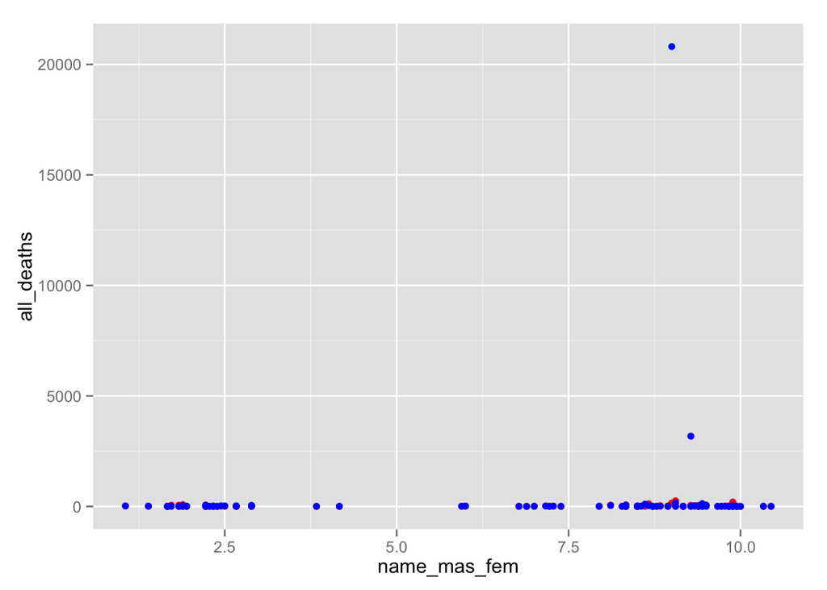

```r
ggplot(hurricanes, aes(x = name_mas_fem, y = all_deaths)) +
  geom_point(color = "red") +
  geom_point(aes(y = pred_count), color = "blue")
```

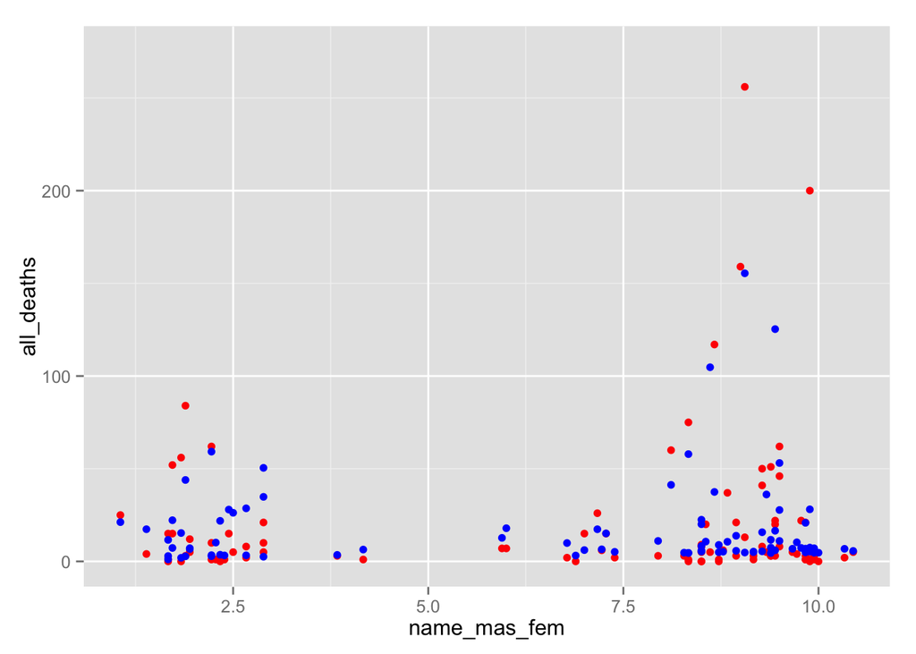

```r
## zoom in
ggplot(hurricanes, aes(x = name_mas_fem, y = all_deaths)) +
  geom_point(color = "red") +
  geom_point(aes(y = pred_count), color = "blue") +
  ylim(0, 275)
```

```r
### Challenge

## predicted counts from original model 3
mfi_male <- hurricanes
mfi_fem <- hurricanes

mfi_male$name_mas_fem <- 1
mfi_fem$name_mas_fem <- 11

pp_mfi_male <- predict(model3, type = "response", newdata = mfi_male)
pp_mfi_male_mean <- mean(pp_mfi_male)
pp_mfi_male_mean
```

```
## [1] 15.76689
```

```r
pp_mfi_fem <- predict(model3, type = "response", newdata = mfi_fem)
pp_mfi_fem_mean <- mean(pp_mfi_fem)
pp_mfi_fem_mean
```

```
## [1] 2693.63
```

```r
###  marginal effect - observed value
pp_mfi_fem_mean  - pp_mfi_male_mean
```

```
## [1] 2677.863
```

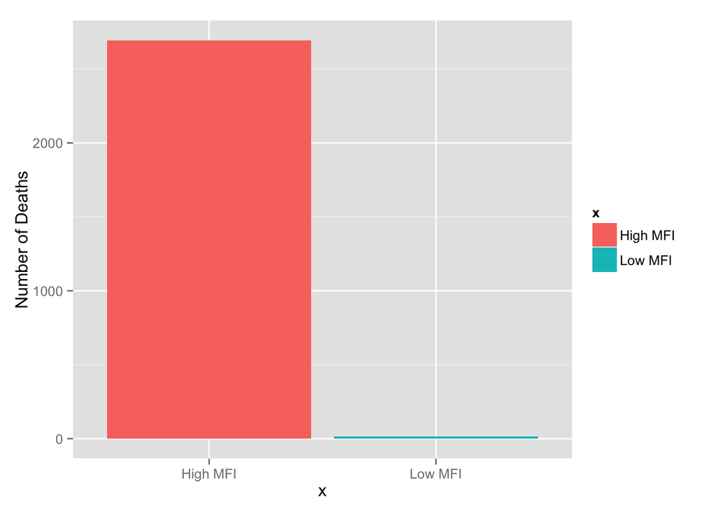

```r
### Graph predicted counts

x <- c("Low MFI", "High MFI")
y <- c(pp_mfi_male_mean, pp_mfi_fem_mean)
graph <- data.frame(x = x, y = y)

ggplot(graph, aes(x = x, y = y, fill = x)) + geom_bar(stat = "identity") +
  ylab("Number of Deaths")
```

## Why log?

- Read about Jeremy Freese post and the discussion section for why normalized damage should be logged (https://scatter.wordpress.com/2014/06/18/why-log/)
- Rerun model 3, this time with the log of normalized damage instead
- Add the fitted values from this model to the scatterplot you made above.
- Challenge: Calculate the predicted counts of fatalities for a MFI score of 1 and 11. Use the observed value approach. Compare this to the predictions of the previous model

```r
model3_log <- glm.nb(all_deaths ~ min_pressure_before +  log(normalized_damage) + name_mas_fem + name_mas_fem:min_pressure_before + name_mas_fem:log(normalized_damage), data = hurricanes)
stargazer(model3_log, type = "text")
```

```
##
## ===============================================================
##                                         Dependent variable:
##                                     ---------------------------
##                                             all_deaths
## ---------------------------------------------------------------
## min_pressure_before                           -0.012
##                                               (0.022)
##
## log(normalized_damage)                        0.336*
##                                               (0.186)
##
## name_mas_fem                                   0.101
##                                               (2.710)
##
## min_pressure_before:name_mas_fem              -0.0002
##                                               (0.003)
##
## log(normalized_damage):name_mas_fem            0.021
##                                               (0.024)
##
## Constant                                      11.110
##                                              (21.885)
##
## ---------------------------------------------------------------
## Observations                                    92
## Log Likelihood                               -311.921
## theta                                    1.082*** (0.180)
## Akaike Inf. Crit.                             635.843
## ===============================================================
## Note:                               *p<0.1; **p<0.05; ***p<0.01
```

```r
pred_count_log <- predict(model3_log, type = "response", newdata = hurricanes)
hurricanes$pred_count_log <- pred_count_log


dplyr::select(hurricanes, pred_count, pred_count_log, all_deaths) ## use dplyr:: because dplyr package is masked by MASS
```

```
## Source: local data frame [92 x 3]
##
##    pred_count pred_count_log all_deaths
## 1    9.908956     11.4755308          2
## 2   17.354156     16.4322286          4
## 3    3.491982      2.8405232          3
## 4    4.861997      1.3377102          1
## 5    4.518379      0.7459182          0
## 6   41.286327     40.9854950         60
## 7   10.677469     18.2294267         20
## 8  125.311747     69.8362923         20
## 9    8.303381     12.8033934          0
## 10  28.083852     27.5084664        200
## ..        ...            ...        ...
```

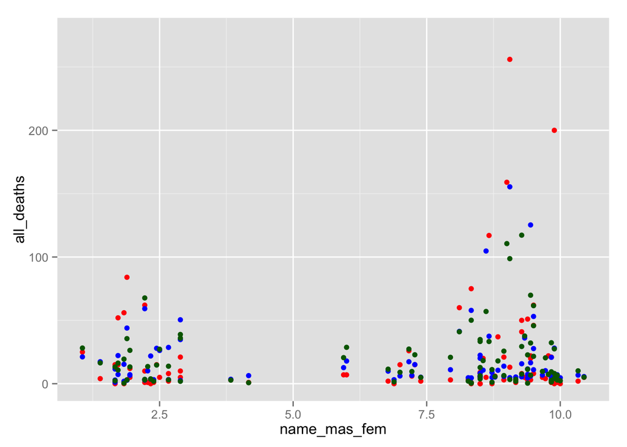

```r
ggplot(hurricanes, aes(x = name_mas_fem, y = all_deaths)) +
  geom_point(color = "red") +
  geom_point(aes(y = pred_count), color = "blue") +
  geom_point(aes(y = pred_count_log), color = "dark green") +
  ylim(0, 275)
```

```r
### Challenge
mfi_male_log <- hurricanes
mfi_fem_log <- hurricanes

mfi_male_log$name_mas_fem <- 1
mfi_fem_log$name_mas_fem <- 11

pp_mfi_male_log <- predict(model3_log, type = "response", newdata = mfi_male_log)
mean_pp_mfi_male_log <- mean(pp_mfi_male_log)
mean_pp_mfi_male_log
```

```
## [1] 13.43205
```

```r
pp_mfi_fem_log <- predict(model3_log, type = "response", newdata = mfi_fem_log)
mean_pp_mfi_fem_log <- mean(pp_mfi_fem_log)
mean_pp_mfi_fem_log
```

```
## [1] 25.42287
```

```r
###  marginal effect
mean_pp_mfi_fem_log  - mean_pp_mfi_male_log
```

```
## [1] 11.99082
```

```r
x_log <- c("Low MFI", "High MFI")
y_log <- c(mean_pp_mfi_male_log , mean_pp_mfi_fem_log)
graph_log <- data.frame(x = x_log, y = y_log)
graph_log
```

```
##          x        y
## 1  Low MFI 13.43205
## 2 High MFI 25.42287
```

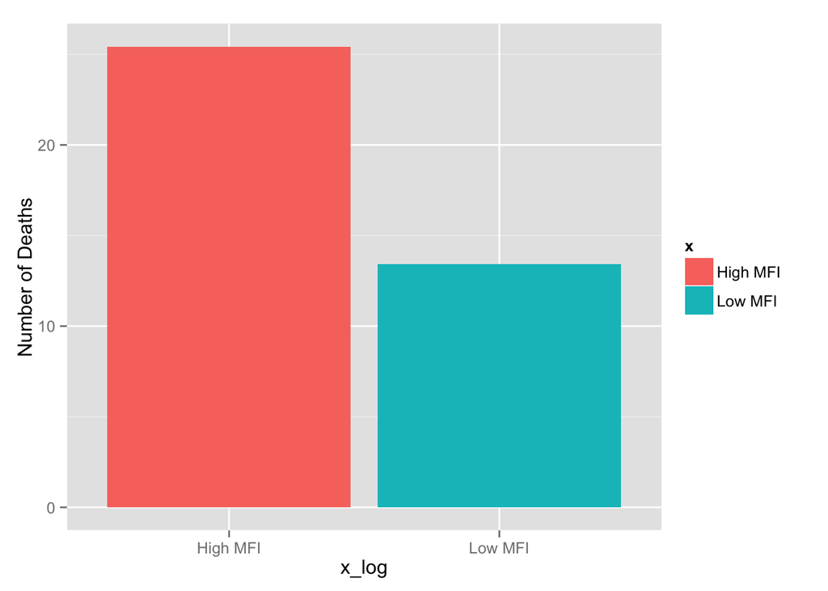

```r
ggplot(graph_log, aes(x = x_log, y = y_log, fill = x)) + geom_bar(stat = "identity") +
  ylab("Number of Deaths")
```

## Let’s talk about ethics

## Goal Check

- Explore some issues and solutions in the hurricane study
- Understand negative binomial regression in terms of predicted counts
- Discuss ethics involved with hurricane study

## Feedback

http://bit.do/soc504_lab

## To see html version

http://htmlpreview.github.io/?https://raw.githubusercontent.com/soc504-s2015-princeton/slides/master/32-lab-hurricanes/32-lab-hurricanes-solutions.html

#### Please don’t delete this; it is helpful for debugging